# Tugas-Pertemuan-1 Lara Tria Novita [M0401241122]

## Library/Packages

*Package* R yang digunakan pada tugas ini adalah: `forecast`, `graphics`, `TTR`, `rio`, `ggplot2`.

```r
#install.packages("forecast")
#install.packages("graphics")
#install.packages("TTR")
#install.packages("rio")
#install.packages("ggplot2")
```

Jika sudah ada, silakan panggil library *package* tersebut.

```r
library("forecast")
```

```r
library("graphics")
library("TTR")
library("rio")
library("ggplot2")
```

## Impor Data

Dataset yang digunakan adalah **Daily Minimum Temperatures in Melbourne, Australia (1981-1990)**, berisi 3.650 observasi suhu minimum harian (°C). Data ini bersifat publik dan memenuhi ketentuan tugas (panjang data ≥ 500 periode).

```r
data1 <- import("https://raw.githubusercontent.com/jbrownlee/Datasets/master/daily-min-temperatures.csv")

#via csv gunakan read.csv("namafile.csv")
#data1 <- read.csv("daily-min-temperatures.csv")

colnames(data1) <- c("Date", "Temp")
data1$Date <- as.Date(data1$Date)
data1$Periode <- 1:nrow(data1)

# menampilkan 5 data pertama
head(data1)
```

```
##         Date Temp Periode
## 1 1981-01-01 20.7       1
## 2 1981-01-02 17.9       2
## 3 1981-01-03 18.8       3
## 4 1981-01-04 14.6       4
## 5 1981-01-05 15.8       5
## 6 1981-01-06 15.8       6
```

```r
cat("Jumlah periode keseluruhan data:", nrow(data1), "\n")
```

```
## Jumlah periode keseluruhan data: 3650
```

## Pembagian Data ke Anggota Kelompok

Kelompok terdiri atas **5 anggota**. Total data (3.650 observasi) dibagi rata menjadi 5 bagian berurutan sebanyak **730 observasi per orang** (jauh di atas ketentuan minimal 100 observasi/orang), tanpa sisa (3.650 ÷ 5 = 730).

| Anggota | Observasi ke- | Rentang Tanggal |
| --- | --- | --- |
| 1 | 1 – 730 | 1 Jan 1981 – 31 Des 1982 |
| 2 | 731 – 1460 | 1 Jan 1983 – 30 Des 1984 |
| 3 | 1461 – 2190 | 31 Des 1984 – 30 Des 1986 |
| 4 | 2191 – 2920 | 31 Des 1986 – 30 Des 1988 |
| 5 | 2921 – 3650 | 31 Des 1988 – 31 Des 1990 |

Bagian yang menjadi tanggung jawab saya adalah **Anggota 1**, yaitu observasi ke-1 s.d. 730 (**1 Januari 1981 – 31 Desember 1982**, tepat 2 tahun data).

```r
jumlah_anggota <- 5
anggota_ke     <- 1          #

n_obs     <- floor(nrow(data1) / jumlah_anggota)
start_idx <- (anggota_ke - 1) * n_obs + 1

data_individu <- data1[start_idx:(start_idx + n_obs - 1), ]
data_individu$Periode <- 1:nrow(data_individu)
rownames(data_individu) <- NULL

cat("Anggota ke-", anggota_ke, "dari", jumlah_anggota, "\n")
```

```
## Anggota ke- 1 dari 5
```

```r
cat("Jumlah observasi bagian individu:", nrow(data_individu), "\n")
```

```
## Jumlah observasi bagian individu: 730
```

```r
cat("Rentang tanggal:", format(min(data_individu$Date)), "s/d", format(max(data_individu$Date)), "\n")
```

```
## Rentang tanggal: 1981-01-01 s/d 1982-12-31
```

## Eksplorasi Data

`View()` : menampilkan data dalam bentuk tabel (buka di tab terpisah di RStudio), `str()` : menampilkan struktur data, `dim()` : menampilkan dimensi data.

```r
View(data_individu)
```

```r
str(data_individu)
```

```
## 'data.frame':    730 obs. of  3 variables:
##  $ Date   : Date, format: "1981-01-01" "1981-01-02" ...
##  $ Temp   : num  20.7 17.9 18.8 14.6 15.8 15.8 15.8 17.4 21.8 20 ...
##  $ Periode: int  1 2 3 4 5 6 7 8 9 10 ...
```

```r
dim(data_individu)
```

```
## [1] 730   3
```

Mengubah data agar terbaca sebagai data deret waktu dengan fungsi `ts()`.

```r
data1.ts <- ts(data_individu$Temp)
summary(data1.ts)
```

```
##    Min. 1st Qu.  Median    Mean 3rd Qu.    Max.
##    0.00    7.80   11.00   11.15   14.20   26.30
```

Membuat plot data deret waktu.

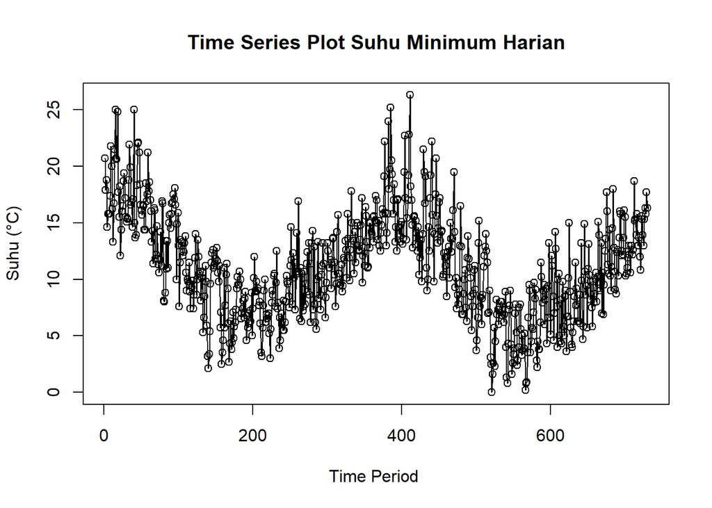

```r
ts.plot(data1.ts, xlab="Time Period ", ylab="Suhu (°C)",
        main = "Time Series Plot Suhu Minimum Harian")
points(data1.ts)
```

```r
#menyimpan plot
dev.copy(png, "plot_data_individu.png")
```

```r
dev.off()
```

Dari plot terlihat data memiliki pola musiman tahunan yang jelas (terlihat dua siklus naik-turun karena rentang datanya mencakup 2 tahun penuh) dengan fluktuasi harian (noise) yang cukup tinggi, namun tidak menunjukkan tren jangka panjang (naik/turun antar tahun) yang kuat pada 730 hari ini.

## Single Moving Average & Double Moving Average

### Pembagian Data

Pembagian data latih dan data uji dilakukan dengan perbandingan 80% data latih dan 20% data uji.

```r
# hitung jumlah data
n <- nrow(data_individu)

# tentukan batas 80%
n_train <- floor(0.8 * n)

# bagi data
training_ma <- data_individu[1:n_train, ]
testing_ma  <- data_individu[(n_train+1):n, ]

# ubah ke time series
train_ma.ts <- ts(training_ma$Temp)
test_ma.ts  <- ts(testing_ma$Temp)

cat("Data latih:", length(train_ma.ts), "| Data uji:", length(test_ma.ts), "\n")
```

```
## Data latih: 584 | Data uji: 146
```

Eksplorasi data dilakukan pada keseluruhan data, data latih, serta data uji menggunakan plot data deret waktu.

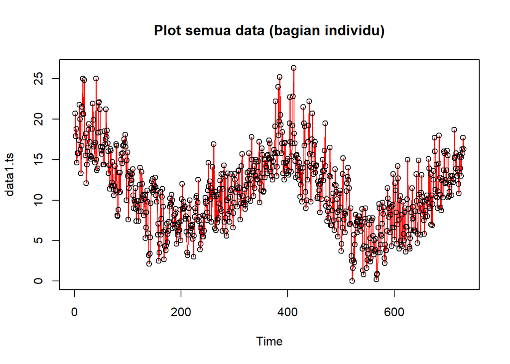

```r
#eksplorasi keseluruhan data
plot(data1.ts, col="red", main="Plot semua data (bagian individu)")
points(data1.ts)
```

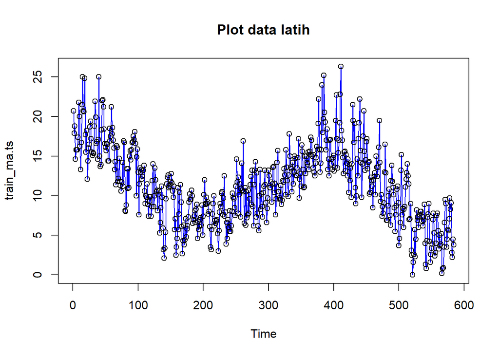

```r
#eksplorasi data latih
plot(train_ma.ts, col="blue", main="Plot data latih")
points(train_ma.ts)
```

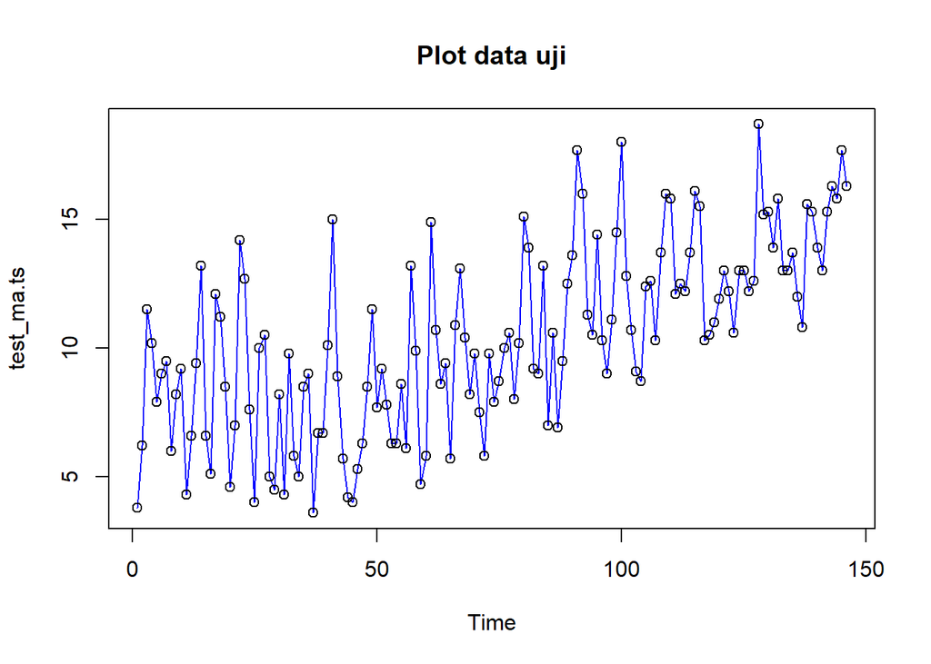

```r
#eksplorasi data uji
plot(test_ma.ts, col="blue", main="Plot data uji")
points(test_ma.ts)
```

Eksplorasi data juga dilakukan menggunakan *package* `ggplot2`.

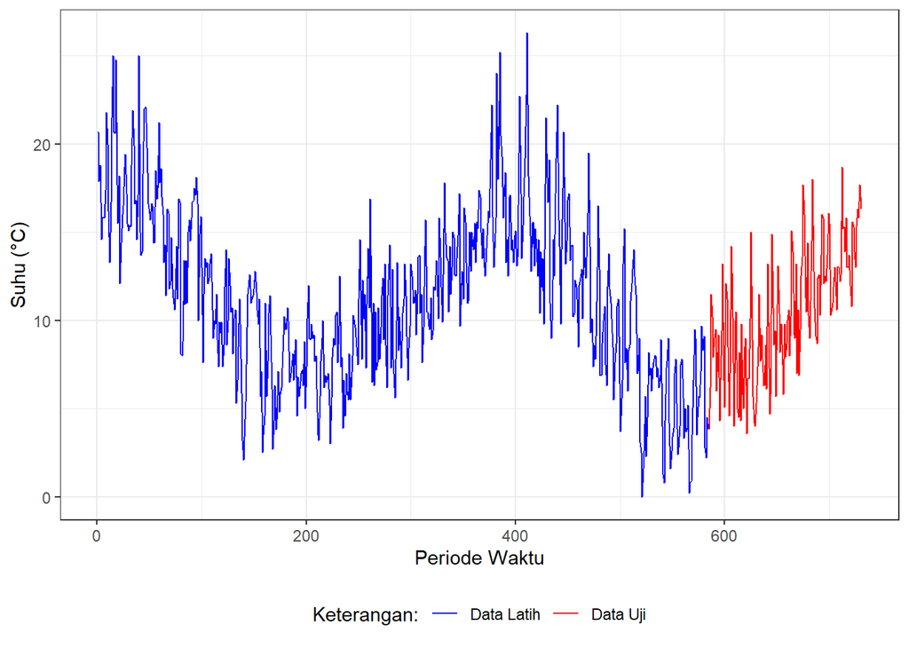

```r
ggplot() +
  geom_line(data = training_ma, aes(x = Periode, y = Temp, col = "Data Latih")) +
  geom_line(data = testing_ma, aes(x = Periode, y = Temp, col = "Data Uji")) +
  labs(x = "Periode Waktu", y = "Suhu (°C)", color = "Legend") +
  scale_colour_manual(name="Keterangan:", breaks = c("Data Latih", "Data Uji"),
                      values = c("blue", "red")) +
  theme_bw() + theme(legend.position = "bottom",
                     plot.caption = element_text(hjust=0.5, size=12))
```

### Single Moving Average (SMA)

Ide dasar dari Single Moving Average (SMA) adalah data suatu periode dipengaruhi oleh data periode sebelumnya. Metode pemulusan ini cocok digunakan untuk pola data stasioner/konstan. Prinsip dasarnya, data pemulusan pada periode ke-t merupakan rata-rata dari m buah data pada periode ke-t hingga periode ke (t-m+1).

$$S_t = \frac{1}{m} \sum_{i=t-m+1}^{t} X_i$$

Data pemulusan pada periode ke-t selanjutnya digunakan sebagai nilai peramalan pada periode ke t+1.

$$F_t = S_{t-1}, \quad F_{n,h} = S_n$$

Pemulusan menggunakan metode SMA dilakukan dengan fungsi `SMA()`. Karena data bersifat harian dengan pola mingguan yang lemah, digunakan parameter `m=7`.

```r
data.sma <- SMA(train_ma.ts, n = 7)
data.sma
```

```
## Time Series:
## Start = 1
## End = 584
## Frequency = 1
##   [1]        NA        NA        NA        NA        NA        NA 17.057143
##   [8] 16.585714 17.142857 17.314286 17.542857 17.185714 17.314286 18.128571
##  [15] 19.214286 19.057143 19.142857 20.371429 21.000000 20.828571 20.357143
##  [22] 18.514286 17.614286 16.957143 15.771429 15.914286 16.471429 16.328571
##  [29] 16.814286 16.914286 16.828571 16.657143 16.671429 17.028571 17.414286
##  [36] 17.571429 17.814286 17.700000 17.957143 18.842857 17.857143 16.971429
##  [43] 16.585714 16.800000 17.857143 18.571429 18.028571 18.514286 18.928571
##  [50] 19.242857 18.871429 18.100000 17.300000 16.328571 15.757143 16.028571
##  [57] 16.142857 16.400000 17.057143 17.242857 17.842857 18.214286 17.857143
##  [64] 17.342857 16.885714 15.485714 15.271429 14.914286 14.171429 13.628571
##  [71] 13.828571 13.471429 13.457143 12.642857 12.014286 12.357143 12.214286
```

[output cut: 73 more lines]

Data pemulusan pada periode ke-t digunakan sebagai nilai peramalan pada periode ke t+1.

```r
data.ramal <- c(NA, data.sma)
tail(data.ramal, 10) #forecast 1 periode ke depan
```

```
##  [1] 6.042857 6.342857 6.414286 6.442857 6.342857 7.142857 6.900000 6.400000
##  [9] 6.242857 5.771429
```

Selanjutnya dilakukan peramalan sebanyak 146 periode sesuai jumlah data uji. Pada metode SMA, seluruh hasil peramalan ke depan bernilai sama dengan hasil ramalan satu periode ke depan (nilai pemulusan terakhir).

```r
h <- length(test_ma.ts)

data.gab <- cbind(
  aktual    = c(data1.ts),
  pemulusan = c(data.sma, rep(NA, h)),
  ramalan   = c(data.ramal, rep(data.ramal[length(data.ramal)], h - 1)))

tail(data.gab, h + 3)
```

```
##        aktual pemulusan  ramalan
## [582,]    2.2  6.400000 6.900000
## [583,]    4.5  6.242857 6.400000
## [584,]    3.8  5.771429 6.242857
## [585,]    3.8        NA 5.771429
## [586,]    6.2        NA 5.771429
## [587,]   11.5        NA 5.771429
## [588,]   10.2        NA 5.771429
## [589,]    7.9        NA 5.771429
## [590,]    9.0        NA 5.771429
## [591,]    9.5        NA 5.771429
## [592,]    6.0        NA 5.771429
## [593,]    8.2        NA 5.771429
## [594,]    9.2        NA 5.771429
## [595,]    4.3        NA 5.771429
```

[output cut: 135 more lines]

Plot deret waktu dari hasil peramalan.

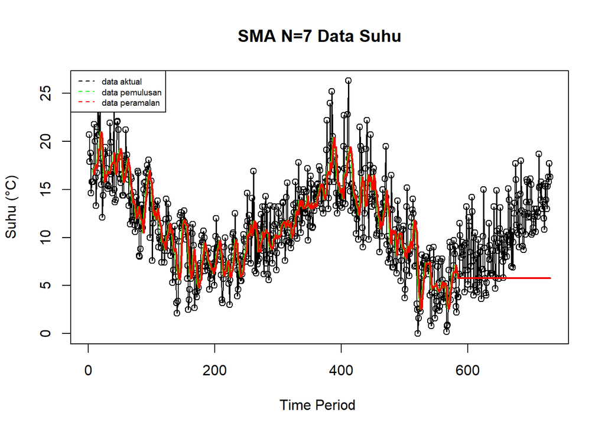

```r
ts.plot(data1.ts, xlab="Time Period ", ylab="Suhu (°C)", main= "SMA N=7 Data Suhu")
points(data1.ts)
lines(data.gab[,2], col="green", lwd=2)
lines(data.gab[,3], col="red", lwd=2)
legend("topleft", c("data aktual","data pemulusan","data peramalan"), lty=8,
       col=c("black","green","red"), cex=0.6)
```

Perhitungan akurasi dilakukan dengan ukuran SSE, MSE, dan MAPE, baik pada data latih maupun data uji.

$$SSE = \sum_{t=1}^{n} (y_t - \hat{y}_t)^2 \qquad
MSE = \frac{1}{n} \sum_{t=1}^{n} (y_t - \hat{y}_t)^2 \qquad
MAPE = \frac{1}{n} \sum_{t=1}^{n} \left|\frac{y_t -
\hat{y}_t}{y_t}\right| \times 100$$

```r
#Menghitung nilai keakuratan data latih
error_train.sma <- train_ma.ts - data.ramal[1:length(train_ma.ts)]

SSE_train.sma  <- sum(error_train.sma[8:length(train_ma.ts)]^2)
MSE_train.sma  <- mean(error_train.sma[8:length(train_ma.ts)]^2)
MAPE_train.sma <- mean(abs((error_train.sma[8:length(train_ma.ts)]/train_ma.ts[8:length(train_ma.ts)])*100))

akurasi_train.sma <- matrix(c(SSE_train.sma, MSE_train.sma, MAPE_train.sma))
row.names(akurasi_train.sma) <- c("SSE", "MSE", "MAPE")
colnames(akurasi_train.sma) <- c("Akurasi m = 7")
akurasi_train.sma
```

```
##      Akurasi m = 7
## SSE    5185.077347
## MSE       8.986269
## MAPE           Inf
```

```r
#Menghitung nilai keakuratan data uji
error_test.sma <- test_ma.ts - data.gab[(n_train+1):n, 3]

SSE_test.sma  <- sum(error_test.sma^2)
MSE_test.sma  <- mean(error_test.sma^2)
MAPE_test.sma <- mean(abs((error_test.sma/test_ma.ts)*100))

akurasi_test.sma <- matrix(c(SSE_test.sma, MSE_test.sma, MAPE_test.sma))
row.names(akurasi_test.sma) <- c("SSE", "MSE", "MAPE")
colnames(akurasi_test.sma) <- c("Akurasi m = 7")
akurasi_test.sma
```

```
##      Akurasi m = 7
## SSE     5007.39204
## MSE       34.29721
## MAPE      41.81139
```

### Double Moving Average (DMA)

Metode DMA pada dasarnya mirip dengan SMA, namun lebih cocok digunakan untuk pola data tren. Proses pemulusan dengan rata-rata dilakukan sebanyak 2 kali.

- **Tahap I:** $S_{1,t} = \frac{1}{m}\sum_{i=t-m+1}^{t} X_i$
- **Tahap II:** $S_{2,t} = \frac{1}{m}\sum_{i=t-m+1}^{t} S_{1,i}$

Forecast $h$ langkah ke depan: $F_{2,t,t+h} = A_t + B_t\,(h)$, dengan $A_t = 2S_{1,t} - S_{2,t}$ dan $B_t = \frac{2}{m-1}(S_{1,t} - S_{2,t})$.

```r
dma <- SMA(data.sma, n = 7)
At  <- 2*data.sma - dma
Bt  <- 2/(7-1)*(data.sma - dma)
data.dma   <- At + Bt
data.ramal2 <- c(NA, data.dma)

t <- 1:h
f <- c()
for (i in t) {
  f[i] <- At[length(At)] + Bt[length(Bt)]*(i)
}

data.gab2 <- cbind(aktual = c(data1.ts),
                   pemulusan1 = c(data.sma, rep(NA, h)),
                   pemulusan2 = c(dma, rep(NA, h)),
                   At = c(At, rep(NA, h)),
                   Bt = c(Bt, rep(NA, h)),
                   ramalan = c(data.ramal2, f[-1]))
tail(data.gab2, h + 3)
```

```
##        aktual pemulusan1 pemulusan2       At          Bt       ramalan
## [582,]    2.2   6.400000   6.569388 6.230612 -0.05646259   7.408843537
## [583,]    4.5   6.242857   6.555102 5.930612 -0.10408163   6.174149660
## [584,]    3.8   5.771429   6.463265 5.079592 -0.23061224   5.826530612
## [585,]    3.8         NA         NA       NA          NA   4.848979592
## [586,]    6.2         NA         NA       NA          NA   4.618367347
## [587,]   11.5         NA         NA       NA          NA   4.387755102
## [588,]   10.2         NA         NA       NA          NA   4.157142857
## [589,]    7.9         NA         NA       NA          NA   3.926530612
## [590,]    9.0         NA         NA       NA          NA   3.695918367
## [591,]    9.5         NA         NA       NA          NA   3.465306122
## [592,]    6.0         NA         NA       NA          NA   3.234693878
## [593,]    8.2         NA         NA       NA          NA   3.004081633
## [594,]    9.2         NA         NA       NA          NA   2.773469388
## [595,]    4.3         NA         NA       NA          NA   2.542857143
```

[output cut: 135 more lines]

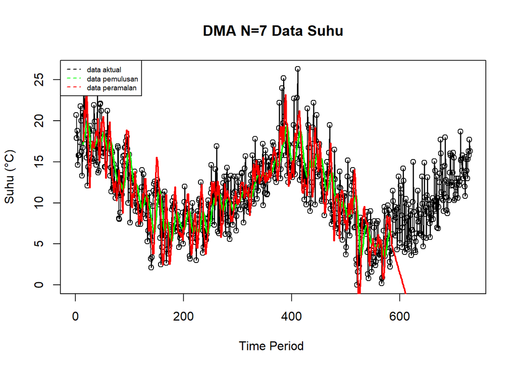

```r
ts.plot(data1.ts, xlab="Time Period ", ylab="Suhu (°C)", main= "DMA N=7 Data Suhu")
points(data1.ts)
lines(data.gab2[,3], col="green", lwd=2)
lines(data.gab2[,6], col="red", lwd=2)
legend("topleft", c("data aktual","data pemulusan","data peramalan"), lty=8,
       col=c("black","green","red"), cex=0.6)
```

```r
#Menghitung nilai keakuratan data latih
error_train.dma <- train_ma.ts - data.ramal2[1:length(train_ma.ts)]

SSE_train.dma  <- sum(error_train.dma[14:length(train_ma.ts)]^2)
MSE_train.dma  <- mean(error_train.dma[14:length(train_ma.ts)]^2)
MAPE_train.dma <- mean(abs((error_train.dma[14:length(train_ma.ts)]/train_ma.ts[14:length(train_ma.ts)])*100))

akurasi_train.dma <- matrix(c(SSE_train.dma, MSE_train.dma, MAPE_train.dma))
row.names(akurasi_train.dma) <- c("SSE", "MSE", "MAPE")
colnames(akurasi_train.dma) <- c("Akurasi m = 7")
akurasi_train.dma
```

```
##      Akurasi m = 7
## SSE     6484.36625
## MSE       11.35616
## MAPE           Inf
```

```r
#Menghitung nilai keakuratan data uji
error_test.dma <- test_ma.ts - data.gab2[(n_train+1):n, 6]

SSE_test.dma  <- sum(error_test.dma^2)
MSE_test.dma  <- mean(error_test.dma^2)
MAPE_test.dma <- mean(abs((error_test.dma/test_ma.ts)*100))

akurasi_test.dma <- matrix(c(SSE_test.dma, MSE_test.dma, MAPE_test.dma))
row.names(akurasi_test.dma) <- c("SSE", "MSE", "MAPE")
colnames(akurasi_test.dma) <- c("Akurasi m = 7")
akurasi_test.dma
```

```
##      Akurasi m = 7
## SSE     94828.3139
## MSE       649.5090
## MAPE      204.6967
```

## Single Exponential Smoothing & Double Exponential Smoothing

Metode *Exponential Smoothing* memberikan bobot yang menurun secara eksponensial pada data historis, sehingga nilai terbaru mendapat bobot lebih besar. SES cocok untuk data tanpa tren/musiman, sedangkan DES mampu menangkap tren.

### Single Exponential Smoothing (SES)

$$\tilde{y}_T=\lambda
y_t+(1-\lambda)\tilde{y}_{T-1}$$

Pemulusan SES dilakukan dengan fungsi `ses()` dari *package* `forecast`, mencoba beberapa nilai $\lambda$ (alpha) serta nilai optimum (`alpha = NULL`).

```r
ses.1 <- ses(train_ma.ts, h = h, alpha = 0.2)
ses.2 <- ses(train_ma.ts, h = h, alpha = 0.7)
ses.opt <- ses(train_ma.ts, h = h, alpha = NULL)

cat("alpha optimum SES:", round(ses.opt$model$par["alpha"], 3), "\n")
```

```
## alpha optimum SES: 0.647
```

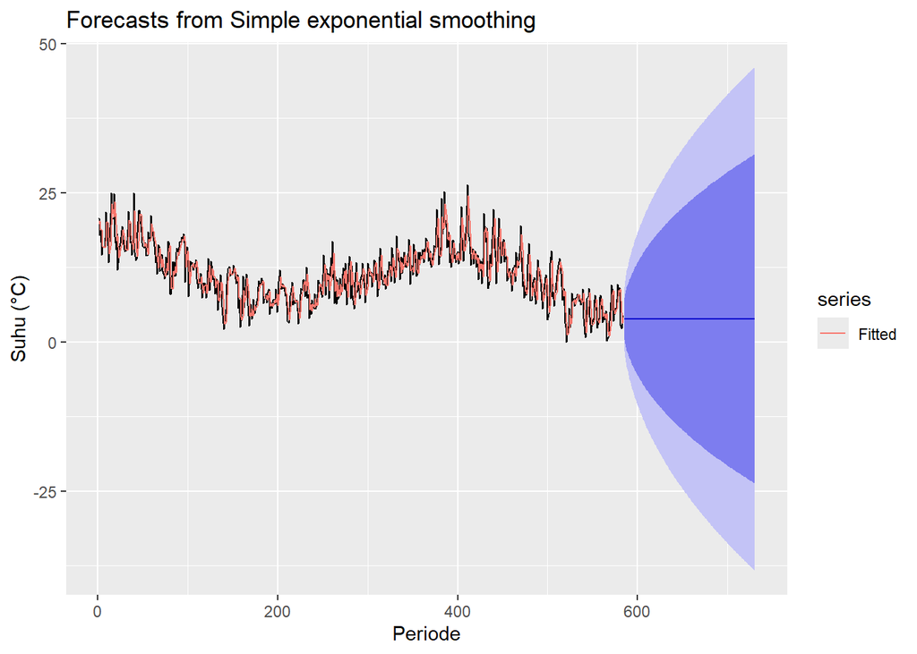

```r
autoplot(ses.opt) +
  autolayer(fitted(ses.opt), series="Fitted") +
  ylab("Suhu (°C)") + xlab("Periode")
```

#### Akurasi Data Latih

```r
# Objek ses() tidak menyimpan $SSE langsung, sehingga dihitung dari residual model
SSE1  <- sum(ses.1$model$residuals^2);   MSE1  <- SSE1/length(train_ma.ts);   RMSE1  <- sqrt(MSE1)
SSE2  <- sum(ses.2$model$residuals^2);   MSE2  <- SSE2/length(train_ma.ts);   RMSE2  <- sqrt(MSE2)
SSEopt<- sum(ses.opt$model$residuals^2); MSEopt<- SSEopt/length(train_ma.ts); RMSEopt<- sqrt(MSEopt)

akurasi_train.ses <- data.frame(
  Skenario = c("alpha=0.2", "alpha=0.7", "alpha optimum"),
  SSE  = c(SSE1, SSE2, SSEopt),
  MSE  = c(MSE1, MSE2, MSEopt),
  RMSE = c(RMSE1, RMSE2, RMSEopt))
akurasi_train.ses
```

```
##        Skenario      SSE      MSE     RMSE
## 1     alpha=0.2 4656.384 7.973261 2.823696
## 2     alpha=0.7 4368.806 7.480833 2.735111
## 3 alpha optimum 4364.787 7.473950 2.733853
```

#### Akurasi Data Uji

```r
# as.numeric() dipakai agar pengurangan tidak terpengaruh atribut index waktu ts()
aktual_uji <- as.numeric(test_ma.ts)
selisih1   <- as.numeric(ses.1$mean)   - aktual_uji
selisih2   <- as.numeric(ses.2$mean)   - aktual_uji
selisihopt <- as.numeric(ses.opt$mean) - aktual_uji

akurasi_test.ses <- data.frame(
  Skenario = c("alpha=0.2", "alpha=0.7", "alpha optimum"),
  SSE  = c(sum(selisih1^2), sum(selisih2^2), sum(selisihopt^2)),
  MSE  = c(mean(selisih1^2), mean(selisih2^2), mean(selisihopt^2)),
  MAPE = c(mean(abs(selisih1/aktual_uji)*100),
           mean(abs(selisih2/aktual_uji)*100),
           mean(abs(selisihopt/aktual_uji)*100)))
akurasi_test.ses
```

```
##        Skenario      SSE      MSE     MAPE
## 1     alpha=0.2 6091.634 41.72352 46.88010
## 2     alpha=0.7 8113.418 55.57135 57.09566
## 3 alpha optimum 8089.728 55.40910 56.96678
```

### Double Exponential Smoothing (DES) / Holt’s Linear Trend

DES menambahkan komponen tren pada persamaan pemulusan, menggunakan dua parameter: $\alpha$ (level) dan $\beta$ (tren). Pemulusan dilakukan dengan fungsi `holt()`.

```r
des.1 <- holt(train_ma.ts, h = h, alpha = 0.2, beta = 0.1)
des.2 <- holt(train_ma.ts, h = h, alpha = 0.7, beta = 0.2)
des.opt <- holt(train_ma.ts, h = h, alpha = NULL, beta = NULL)

cat("alpha optimum:", round(des.opt$model$par["alpha"], 3),
    "| beta optimum:", round(des.opt$model$par["beta"], 3), "\n")
```

```
## alpha optimum: 0.647 | beta optimum: 0
```

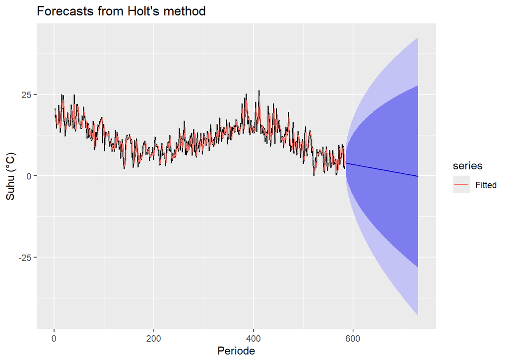

```r
autoplot(des.opt) +
  autolayer(fitted(des.opt), series="Fitted") +
  ylab("Suhu (°C)") + xlab("Periode")
```

#### Akurasi Data Latih

```r
# Objek holt() tidak menyimpan $SSE langsung, sehingga dihitung dari residual model
SSEd1  <- sum(des.1$model$residuals^2);   MSEd1  <- SSEd1/length(train_ma.ts);   RMSEd1  <- sqrt(MSEd1)
SSEd2  <- sum(des.2$model$residuals^2);   MSEd2  <- SSEd2/length(train_ma.ts);   RMSEd2  <- sqrt(MSEd2)
SSEdopt<- sum(des.opt$model$residuals^2); MSEdopt<- SSEdopt/length(train_ma.ts); RMSEdopt<- sqrt(MSEdopt)

akurasi_train.des <- data.frame(
  Skenario = c("alpha=0.2;beta=0.1", "alpha=0.7;beta=0.2", "optimum"),
  SSE  = c(SSEd1, SSEd2, SSEdopt),
  MSE  = c(MSEd1, MSEd2, MSEdopt),
  RMSE = c(RMSEd1, RMSEd2, RMSEdopt))
akurasi_train.des
```

```
##             Skenario      SSE       MSE     RMSE
## 1 alpha=0.2;beta=0.1 6939.256 11.882287 3.447069
## 2 alpha=0.7;beta=0.2 5526.248  9.462753 3.076159
## 3            optimum 4365.295  7.474820 2.734012
```

#### Akurasi Data Uji

```r
dselisih1   <- as.numeric(des.1$mean)   - aktual_uji
dselisih2   <- as.numeric(des.2$mean)   - aktual_uji
dselisihopt <- as.numeric(des.opt$mean) - aktual_uji

akurasi_test.des <- data.frame(
  Skenario = c("alpha=0.2;beta=0.1", "alpha=0.7;beta=0.2", "optimum"),
  SSE  = c(sum(dselisih1^2), sum(dselisih2^2), sum(dselisihopt^2)),
  MSE  = c(mean(dselisih1^2), mean(dselisih2^2), mean(dselisihopt^2)),
  MAPE = c(mean(abs(dselisih1/aktual_uji)*100),
           mean(abs(dselisih2/aktual_uji)*100),
           mean(abs(dselisihopt/aktual_uji)*100)))
akurasi_test.des
```

```
##             Skenario        SSE        MSE     MAPE
## 1 alpha=0.2;beta=0.1 1324007.95 9068.54757 780.6869
## 2 alpha=0.7;beta=0.2  306037.36 2096.14632 377.8569
## 3            optimum   13657.66   93.54559  76.4544
```

#### Perbandingan SES dan DES

```r
MSEfull <- matrix(c(MSEopt, MSEdopt), nrow=1, ncol=2)
colnames(MSEfull) <- c("ses (optimum)", "des (optimum)")
row.names(MSEfull) <- "MSE data uji"
MSEfull
```

```
##              ses (optimum) des (optimum)
## MSE data uji       7.47395       7.47482
```

## Pemulusan dengan Holt-Winters

Data suhu memiliki pola musiman **tahunan** yang cukup jelas terlihat pada plot (2 siklus penuh dalam 730 hari). Namun demikian, setelah data dibagi latih:uji (80:20), data latih hanya berisi ± 584 hari (± 1,6 tahun) — belum genap 2 siklus tahunan penuh (2×365 hari), sehingga `HoltWinters()` tidak dapat difit dengan periode musiman tahunan (`frequency = 365`) pada data latih. Oleh karena itu, sebagai pembanding tetap digunakan periode musiman **mingguan** (`frequency = 7`), dengan catatan hasil ini bersifat eksploratif karena pola mingguan pada data suhu memang tidak sekuat pola tahunannya.

```r
train_hw.ts <- ts(training_ma$Temp, frequency = 7)
test_hw.ts  <- ts(testing_ma$Temp, frequency = 7)

winter.opt <- HoltWinters(train_hw.ts, alpha = NULL, beta = NULL, gamma = NULL,
                           seasonal = "additive")
winter.opt
```

```
## Holt-Winters exponential smoothing with trend and additive seasonal component.
##
## Call:
## HoltWinters(x = train_hw.ts, alpha = NULL, beta = NULL, gamma = NULL,     seasonal = "additive")
##
## Smoothing parameters:
##  alpha: 0.489469
##  beta : 0.002944671
##  gamma: 0.2173314
##
## Coefficients:
##            [,1]
## a   5.779693787
## b   0.004910201
## s1 -0.932689894
## s2 -0.912657172
## s3 -1.084140948
## s4 -1.406290424
## s5 -2.210035178
## s6 -1.723204506
## s7 -1.892033842
```

```r
xhat <- winter.opt$fitted[,1]
```

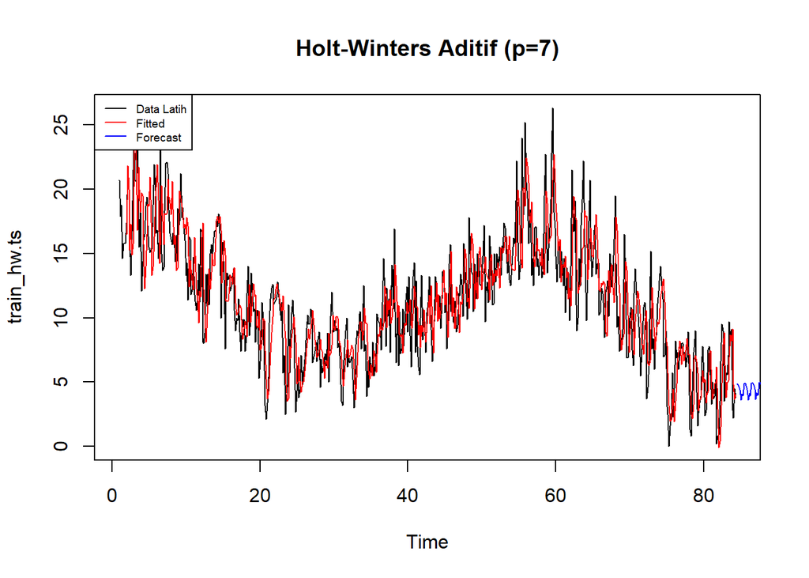

```r
forecast.hw <- predict(winter.opt, n.ahead = h)

plot(train_hw.ts, main="Holt-Winters Aditif (p=7)", type="l", col="black")
lines(xhat, type="l", col="red")
lines(forecast.hw, type="l", col="blue")
legend("topleft", c("Data Latih","Fitted","Forecast"), col=c("black","red","blue"),
       lty=1, cex=0.6)
```

```r
SSEhw <- winter.opt$SSE
MSEhw <- SSEhw/length(train_hw.ts)
RMSEhw <- sqrt(MSEhw)

akurasi_train.hw <- matrix(c(SSEhw, MSEhw, RMSEhw))
row.names(akurasi_train.hw) <- c("SSE", "MSE", "RMSE")
colnames(akurasi_train.hw) <- c("Akurasi (data latih)")
akurasi_train.hw
```

```
##      Akurasi (data latih)
## SSE           4890.039275
## MSE              8.373355
## RMSE             2.893675
```

```r
selisih.hw <- as.numeric(forecast.hw) - aktual_uji
SSEtest.hw  <- sum(selisih.hw^2)
MSEtest.hw  <- mean(selisih.hw^2)
MAPEtest.hw <- mean(abs(selisih.hw/aktual_uji)*100)

akurasi_test.hw <- matrix(c(SSEtest.hw, MSEtest.hw, MAPEtest.hw))
row.names(akurasi_test.hw) <- c("SSE", "MSE", "MAPE")
colnames(akurasi_test.hw) <- c("Akurasi (data uji)")
akurasi_test.hw
```

```
##      Akurasi (data uji)
## SSE          6565.58755
## MSE            44.96978
## MAPE           50.24712
```

## Perbandingan Seluruh Metode & Kesimpulan

Rekap akurasi **data uji** (out-of-sample) dari seluruh metode yang diterapkan, karena akurasi data uji lebih mencerminkan kemampuan generalisasi model dibanding data latih.

```r
rekap <- data.frame(
  Metode = c("SMA (m=7)", "DMA (m=7)", "SES (optimum)", "DES (optimum)", "Holt-Winters (p=7)"),
  SSE  = c(SSE_test.sma, SSE_test.dma, sum(selisihopt^2), sum(dselisihopt^2), SSEtest.hw),
  MSE  = c(MSE_test.sma, MSE_test.dma, mean(selisihopt^2), mean(dselisihopt^2), MSEtest.hw),
  MAPE = c(MAPE_test.sma, MAPE_test.dma,
           mean(abs(selisihopt/test_ma.ts)*100),
           mean(abs(dselisihopt/test_ma.ts)*100),
           MAPEtest.hw)
)
rekap <- rekap[order(rekap$MSE), ]
rekap
```

```
##               Metode       SSE       MSE      MAPE
## 1          SMA (m=7)  5007.392  34.29721  41.81139
## 5 Holt-Winters (p=7)  6565.588  44.96978  50.24712
## 3      SES (optimum)  8089.728  55.40910  56.96678
## 4      DES (optimum) 13657.657  93.54559  76.45440
## 2          DMA (m=7) 94828.314 649.50900 204.69665
```

```r
metode_terbaik <- rekap$Metode[1]
cat("Metode terbaik berdasarkan MSE data uji adalah:", metode_terbaik, "\n")
```

```
## Metode terbaik berdasarkan MSE data uji adalah: SMA (m=7)
```

**Kesimpulan:**

Secara umum, pemilihan metode pemulusan terbaik sangat bergantung pada karakteristik pola data (tren, musiman, noise) — bukan metode yang lebih kompleks yang otomatis lebih unggul, melainkan metode yang paling sesuai dengan pola sebenarnya dalam data.

*Dataset: Daily Minimum Temperatures, Melbourne (Jason Brownlee’s Datasets, GitHub) — `https://raw.githubusercontent.com/jbrownlee/Datasets/master/daily-min-temperatures.csv`*